# DS350 - Final Project

Ashutosh Agarwal

### The Problem

In this project, I am going to recreate the Kaggle competition to predict salaries based on job descriptions. This problem came from a company called Adzuna, “The UK’s Search Engine for Jobs, Property and Cars.” They wanted to be able to predict the salary of a job based on it’s description.

### The Data

There were four files availbale initially, I have merged them to make the problem simpler. There are two files available now.

JobData.csv and location_tree.txt

location_tree.txt has a fairly simple but non-standard format for the a hierarchy of UK locations. JobData.csv contains data for many job posting across varios industries. I want to predict SalaryNormalized.

### What I did

I broke the data set into training and testing sets. I did some exploratory analysis on training set and removed few columns from analysis.

I was unable to use FUll Description for feature extraction as even after doing basic cleaning I was unable to get meaningful features (skill sets). However I will try to do that later.

I used liner model for prediction. RMSE is not to good but hope that after extracting features from Full Description it will be much better.

P.S: I tried Laso regression for model but that did not work well hence I removed that from the code.

### Begin

```r
############################ Function 1 ############################
loadAllLocations = function(x){
  loginfo(paste('Fun: loadAllLocations : Getting list of all locations.'),logger='logger_name')
  #Load location tree as csv
  cols = c(1:7)
  locationtreecsv = read.csv(x,sep = '~', header = FALSE,quote = "", col.names = cols)
  locationtreecsv$X1 = gsub('"','',locationtreecsv$X1)
  locationtreecsv$X2 = gsub('"','',locationtreecsv$X2)
  locationtreecsv$X3 = gsub('"','',locationtreecsv$X3)
  locationtreecsv$X4 = gsub('"','',locationtreecsv$X4)
  locationtreecsv$X5 = gsub('"','',locationtreecsv$X5)
  locationtreecsv$X6 = gsub('"','',locationtreecsv$X6)
  locationtreecsv$X7 = gsub('"','',locationtreecsv$X7)

  l = stack(locationtreecsv)
  l = unique(stack(locationtreecsv)[, "values"])
  return (l)
}
```

```r
############################ Function 2 ############################

allStopWords = function(){
  loginfo(paste('Fun: allStopWords : Begin: Preparing list of all stopwords.'),logger='logger_name')

  my_stops = as.character(sapply(stopwords(), function(x) gsub("'","",x)))

  #Add locations to stop words
  locations = loadAllLocations('location_tree.txt')

  my_stops = c(my_stops, tolower(locations))

  my_stops = c(my_stops, "job", "jobs","title", "client", "result", "person", "opportunity", "due"
              ,"skill","skills","require", "required","requires", "summary"
              ,"benefits", "benefit", "hour", "hours", "time", "sunday", "monday"
              ,"tuesday", "wednesday","thursday","friday","saturday" ,"month", "months"
              ,"asap","include","including","ref","date","role","week", "****"
              ,"success", "successful", "salary", "current", "currently", "look", "looking"
              ,"leading", "company" ,"large", "largest", "seek", "seeker", "seeking", "worker"
              ,"exciting", "qualified", "workers", "career", "per", "annum", "k", "experience"
              ,"experienced", "apply", "applying")

  loginfo(paste('Fun: allStopWords : End: Preparing list of all stopwords.'),logger='logger_name')
  return (my_stops)
}
```

```r
############################ Function 3 ############################

normaliza_text = function(x, s){
  loginfo(paste('Fun: normaliza_text : Begin: Normalizing unstructured text.'),logger='logger_name')

  # Remove non-ascii
  x = iconv(x, from="latin1", to="ASCII", sub="")

  # Change to lower case:
  x = tolower(x)

  # Remove punctuation
  x = sapply(x, function(x) gsub("'", "", x))

  # Now the rest of the punctuation
  x = sapply(x, function(x) gsub("[[:punct:]]", " ", x))

  # Remove numbers
  x = sapply(x, function(x) gsub("\\d","",x))

  # Remove extra white space, so we can split words by spaces
  x = sapply(x, function(x) gsub("[ ]+"," ",x))

  # remove stopwords:
  x = sapply(x, function(x){
    paste(setdiff(strsplit(x," ")[[1]],s),collapse=" ")
  })

  # Remove extra white space again:
  x = sapply(x, function(x) gsub("[ ]+"," ",x))

  loginfo(paste('Fun: normaliza_text : End: Normalizing unstructured text.'),logger='logger_name')
  return(x)
}
```

```r
############################ Function 4 ############################

formDocumentTermMatrix = function(x, percentSparse){
  loginfo(paste('Fun: formDocumentTermMatrix : Begin: Create document term matrix.'),logger='logger_name')
  ##-----Text Corpus-----
  text_corpus = Corpus(VectorSource(x))

  ## Term document matrix and document term matrix
  document_term_matrix = DocumentTermMatrix(text_corpus)

  ## remove sparse terms
  document_term_matrix = removeSparseTerms(document_term_matrix, percentSparse) # Play with the % criteria, start low and work up

  # Save Matrix (This is mostly empty)
  document_term_matrix = as.matrix(document_term_matrix)

  loginfo(paste('Fun: formDocumentTermMatrix : End: Create document term matrix.'),logger='logger_name')
  #Return Data Frame
  return(as.data.frame(document_term_matrix))
}
```

```r
############################ Function 5 ############################
normalizeLocationData = function(x, locationtree){
  loginfo(paste('Fun: normalizeLocationData : Begin: reducung location information to zones.'),logger='logger_name')

  for (i in 1:length(x)) {
    # get city name from training dataset
    locNorm = x[i]

    # Find line number in location tree where above city appears
    line.id = which(grepl(locNorm, locationtree))[1]

    # find broad location (e.g. "UK~South East England~Hampshire~Basingstoke" --> South East England)
    broadLocation = regexpr("~.+?~", locationtree[line.id])
    match = regmatches(locationtree[line.id], broadLocation)

    #For debuggig
    #print(paste(i, ' - ', line.id, ' - ', match))

    # store the broad location in training dataset
    x[i] = gsub("~", "", match)
  }
  loginfo(paste('Fun: normalizeLocationData : End: reducung location information to zones.'),logger='logger_name')

  return(x)
}
```

### Loading Data

```r
#Load given data set
jobData = read.csv('JobData.csv',stringsAsFactors = TRUE)
head(jobData,1)
```

```
##         Id                       Title
## 1 12612628 Engineering Systems Analyst
##                                                                                                                                                                                                                                                                                                          …
## 1 Engineering Systems Analyst Dorking Surrey Salary ****K Our client is located in Dorking, Surrey and are looking for Engineering Systems Analyst our client provides specialist software development Keywords Mathematical Modelling, Risk Analysis, System Modelling, Optimisation, MISER, PIONEEER En…
##               LocationRaw LocationNormalized ContractType ContractTime
## 1 Dorking, Surrey, Surrey            Dorking                 permanent
##                        Company         Category                  SalaryRaw
## 1 Gregory Martin International Engineering Jobs 20000 - 30000/annum 20-30K
##   SalaryNormalized       SourceName
## 1            25000 cv-library.co.uk
```

```r
#There are too many job categories in this data set which will make keyword extraction really difficult
#  from job description. Hence filtering this data only for IT Jobs
jobData = jobData[jobData$Category=='IT Jobs',]
```

```r
#Load location tree that has tre elike structure for cities in UK. (e.g. "UK~South East England~Hampshire~Basingstoke")
locationtree = readLines('location_tree.txt')
head(locationtree)
```

```
## [1] "\"UK~London~East London~Mile End\""
## [2] "\"UK~London~East London~Shadwell\""
## [3] "\"UK~London~East London~Spitalfields\""
## [4] "\"UK~London~East London~Stepney\""
## [5] "\"UK~London~East London~Wapping\""
## [6] "\"UK~London~East London~Whitechapel\""
```

```r
#Generate stop words.
stop_words = allStopWords()
```

```
## 2016-03-09 01:19:06 INFO:logger_name:Fun: allStopWords : Begin: Preparing list of all stopwords.
## 2016-03-09 01:19:06 INFO:logger_name:Fun: loadAllLocations : Getting list of all locations.
## 2016-03-09 01:19:07 INFO:logger_name:Fun: allStopWords : End: Preparing list of all stopwords.
```

### Split Data

```r
# Split into train/test set 75% train / 25% test'
train_ind = sample(1:nrow(jobData), round(0.75*nrow(jobData)))
train_set = jobData[train_ind,]
test_set = jobData[-train_ind,]
```

### Look at summary of various features

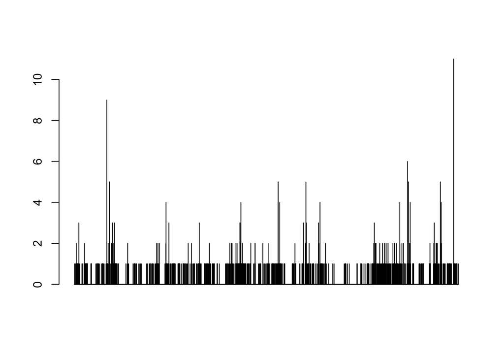

```r
#1. Title...
t = table(train_set$Title)
barplot(t)
```

```r
#Too many titles. It can not be used as a feature directly. Since it contains key info, it can be sliced
#for further feture extraction.
```

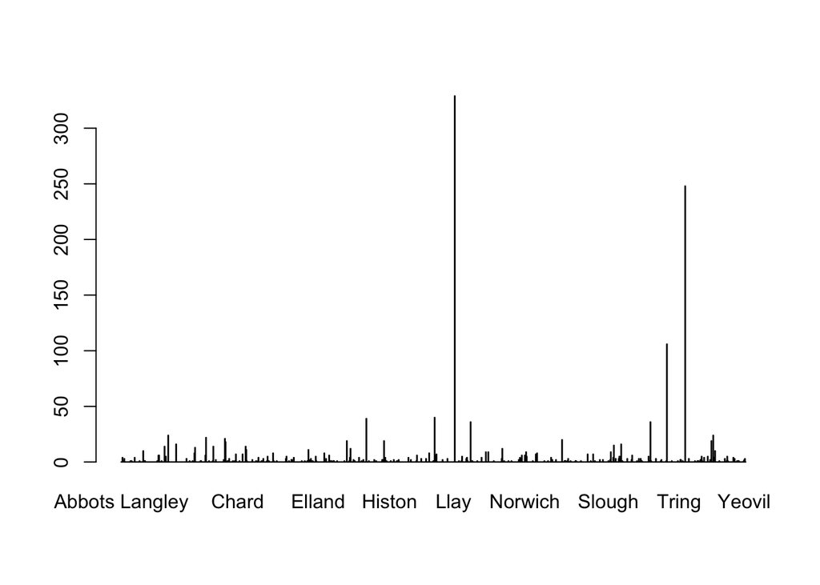

```r
#2. Location...
t = table(train_set$LocationNormalized)
barplot(t)
```

```r
#Too many cities aprox 28% others.
# We will try to reduce number of cities by normalizing them to zones.
```

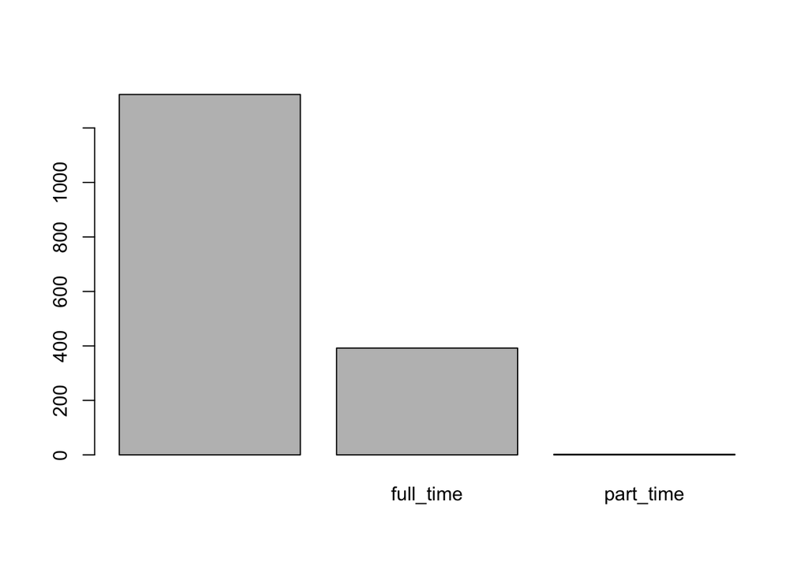

```r
#3. ContractType...
t = table(train_set$ContractType)
barplot(t)
```

```r
#Lot of missing data. No good feature.
```

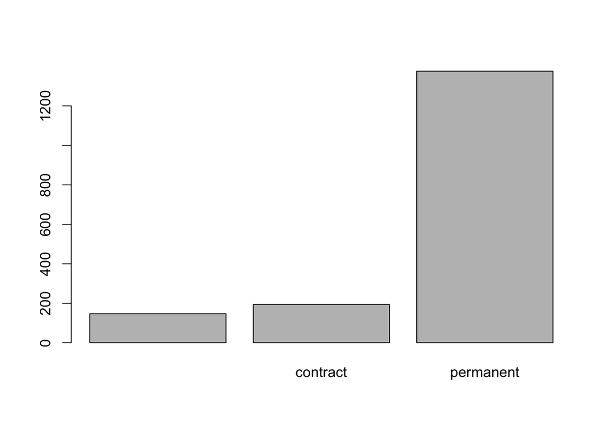

```r
#4. ContractTime...For some; this data is not available.
t = table(train_set$ContractTime)
barplot(t)
```

```r
#Contract and permanent only. Good candidate for prediction feature.
```

```r
#We saw that there were too many cities; as we have location tree; we can normalize that data
#by replacing cities with their broad locations.
## COMMENTING AS THIS METHOD HAS SOME ISSUES ##
#train_set$location = normalizeLocationData(train_set$LocationNormalized,locationtree)

#convert this new column to factor.
#train_set$Location <- as.factor(train_set$Location)

#Locations look much better now.
#summary(train_set$Location)
```

```r
#Remove those columns that we are not going to use later
train_set <- train_set[-c(4,6,10,12)]
```

### Deal with unstructured columns - Training Set

```r
#1. normalizing and stemming "Full Description" column
train_set$FullDescriptionCleaned = normaliza_text(train_set$FullDescription, stop_words)
```

```
## 2016-03-09 01:19:13 INFO:logger_name:Fun: normaliza_text : Begin: Normalizing unstructured text.
## 2016-03-09 01:19:18 INFO:logger_name:Fun: normaliza_text : End: Normalizing unstructured text.
```

```r
# Stem words: Full Description
train_set$FullDescriptionCleanedStem = sapply(train_set$FullDescriptionCleaned, function(x){
  paste(setdiff(wordStem(strsplit(x," ")[[1]]),""),collapse=" ")
})

#2. normalizing and stemming "title" column
train_set$TitleCleaned = normaliza_text(train_set$Title, stop_words)
```

```
## 2016-03-09 01:19:19 INFO:logger_name:Fun: normaliza_text : Begin: Normalizing unstructured text.
## 2016-03-09 01:19:22 INFO:logger_name:Fun: normaliza_text : End: Normalizing unstructured text.
```

```r
# Stem words: title
train_set$TitleCleanedStem = sapply(train_set$TitleCleaned, function(x){
  paste(setdiff(wordStem(strsplit(x," ")[[1]]),""),collapse=" ")
})
```

### Feature Engineering

```r
#We have two columns that have unstructured data
#1 FullDescription - I have less hope with this column as I dont have full list of skill keywords.
#                      I tried using various APIs but no luck. However we will try this.
#1 Title - This looks promising as there is no detailed vebose. Keyword extraction should be effective here.

#  1 FullDescription'
Jobs_term_df = formDocumentTermMatrix(train_set$FullDescriptionCleanedStem, 0.9)
```

```
## 2016-03-09 01:19:22 INFO:logger_name:Fun: formDocumentTermMatrix : Begin: Create document term matrix.
## 2016-03-09 01:19:24 INFO:logger_name:Fun: formDocumentTermMatrix : End: Create document term matrix.
```

```r
#  2 Title'
Jobs_term_title_df = formDocumentTermMatrix(train_set$TitleCleanedStem, 0.98)
```

```
## 2016-03-09 01:19:24 INFO:logger_name:Fun: formDocumentTermMatrix : Begin: Create document term matrix.
## 2016-03-09 01:19:25 INFO:logger_name:Fun: formDocumentTermMatrix : End: Create document term matrix.
```

```r
# Fit all features in one box
#Jobs_term_title_df$LocationNormalized = train_set$LocationNormalized
#Jobs_term_title_df$Company = train_set$Company
Jobs_term_title_df$ContractTime = train_set$ContractTime
Jobs_term_title_df$SalaryNormalized = train_set$SalaryNormalized
```

### Modelling - Using Title Features only

```r
#There were too many irrelevant features for Full description but I could fetch good features from title.
#Hence modelling based on features extracted from title. Fitting linear model.
#I tried with all variables first but due to mismatched features between training and test data sets,
#I was unable to test the model. Hence I removed location and company.'

lm.fit1 <- lm(SalaryNormalized ~ ., data = Jobs_term_title_df)
summary(lm.fit1)
```

```
##
## Call:
## lm(formula = SalaryNormalized ~ ., data = Jobs_term_title_df)
##
## Residuals:
##    Min     1Q Median     3Q    Max
## -47370  -8903  -1191   7778  93892
##
## Coefficients:
##                       Estimate Std. Error t value Pr(>|t|)
## (Intercept)           37532.66    1460.19  25.704  < 2e-16 ***
## administr              -618.96    2824.53  -0.219  0.82657
## analyst               -1515.31    1318.64  -1.149  0.25066
## applic                 6388.29    2280.23   2.802  0.00514 **
## architect             23211.57    2177.91  10.658  < 2e-16 ***
## aspnet                 -777.50    2090.03  -0.372  0.70993
## busi                   8926.97    1828.67   4.882 1.15e-06 ***
## consult               12231.72    1513.08   8.084 1.19e-15 ***
## data                    507.02    2380.91   0.213  0.83139
## design                -1281.25    2052.57  -0.624  0.53257
## develop                3313.19    1105.75   2.996  0.00277 **
## digit                  3702.66    2672.77   1.385  0.16614
## engin                  1966.69    1236.95   1.590  0.11203
## java                    539.82    1835.99   0.294  0.76878
## lead                  14071.00    1986.46   7.083 2.06e-12 ***
## line                  -4826.04    2625.44  -1.838  0.06621 .
## linux                  5525.41    2615.63   2.112  0.03479 *
## manag                 12552.30    1329.58   9.441  < 2e-16 ***
## net                   -2767.79    1896.41  -1.459  0.14462
## network                3723.42    2148.63   1.733  0.08329 .
## oracl                 11936.17    2574.74   4.636 3.83e-06 ***
## php                   -2710.00    2341.61  -1.157  0.24731
## programm              11673.09    2550.28   4.577 5.06e-06 ***
## project                -681.14    2051.02  -0.332  0.73986
## sale                  -2668.47    2630.03  -1.015  0.31043
## senior                 6031.61    1167.20   5.168 2.65e-07 ***
## server                   16.78    2677.62   0.006  0.99500
## servic                -3649.26    1874.15  -1.947  0.05168 .
## softwar               -2861.81    1373.92  -2.083  0.03741 *
## sql                   -1440.39    1946.50  -0.740  0.45941
## support               -9453.18    1497.16  -6.314 3.47e-10 ***
## system                 -131.98    2122.95  -0.062  0.95044
## technic               -2305.62    1738.94  -1.326  0.18506
## test                  -1283.89    1890.59  -0.679  0.49717
## web                   -3489.99    1668.08  -2.092  0.03657 *
## ContractTimecontract  18430.50    1684.41  10.942  < 2e-16 ***
## ContractTimepermanent -1165.32    1345.72  -0.866  0.38664
## ---
## Signif. codes:  0 '***' 0.001 '**' 0.01 '*' 0.05 '.' 0.1 ' ' 1
##
## Residual standard error: 15120 on 1680 degrees of freedom
## Multiple R-squared:  0.329,  Adjusted R-squared:  0.3146
## F-statistic: 22.88 on 36 and 1680 DF,  p-value: < 2.2e-16
```

### Prepare test data

```r
#Remove those columns that we are not going to use later
test_set <- test_set[-c(4,6,10,12)]

#1. normalizing and stemming "Full Description" column
test_set$FullDescriptionCleaned = normaliza_text(test_set$FullDescription, stop_words)
```

```
## 2016-03-09 01:19:25 INFO:logger_name:Fun: normaliza_text : Begin: Normalizing unstructured text.
## 2016-03-09 01:19:27 INFO:logger_name:Fun: normaliza_text : End: Normalizing unstructured text.
```

```r
# Stem words: Full Description
test_set$FullDescriptionCleanedStem = sapply(test_set$FullDescriptionCleaned, function(x){
  paste(setdiff(wordStem(strsplit(x," ")[[1]]),""),collapse=" ")
})

#2. normalizing and stemming "title" column
test_set$TitleCleaned = normaliza_text(test_set$Title, stop_words)
```

```
## 2016-03-09 01:19:27 INFO:logger_name:Fun: normaliza_text : Begin: Normalizing unstructured text.
## 2016-03-09 01:19:28 INFO:logger_name:Fun: normaliza_text : End: Normalizing unstructured text.
```

```r
# Stem words: title
test_set$TitleCleanedStem = sapply(test_set$TitleCleaned, function(x){
  paste(setdiff(wordStem(strsplit(x," ")[[1]]),""),collapse=" ")
})
```

```r
#Standardizing test data as per model needs.
test_Jobs_term_title_df = formDocumentTermMatrix(test_set$TitleCleanedStem, 0.98)
```

```
## 2016-03-09 01:19:28 INFO:logger_name:Fun: formDocumentTermMatrix : Begin: Create document term matrix.
## 2016-03-09 01:19:28 INFO:logger_name:Fun: formDocumentTermMatrix : End: Create document term matrix.
```

```r
# Fit all features in one box
#test_Jobs_term_title_df$LocationNormalized = test_set$LocationNormalized
#test_Jobs_term_title_df$Company = test_set$Company
test_Jobs_term_title_df$ContractTime = test_set$ContractTime
test_Jobs_term_title_df$SalaryNormalized = test_set$SalaryNormalized

#Some features that were in training set are not in test set. Inserting those without making any effect.
getModified <- function(dframe, destination_string, foo) {
  dframe[[destination_string]] <- foo
  dframe
}

c1 = colnames(Jobs_term_title_df)
c2 = colnames(test_Jobs_term_title_df)

l1 = which(is.na(match(c1, c2))==TRUE)

for(i in l1){
  cn = colnames(Jobs_term_title_df)
  test_Jobs_term_title_df = getModified(test_Jobs_term_title_df, cn[i], 0)
}
```

```r
#prediction using lm.fit1
lm.pred1 = predict(lm.fit1, newdata = test_Jobs_term_title_df)
```

```r
#calculate RMSE
RMSE = sqrt(mean((lm.pred1 - test_Jobs_term_title_df$SalaryNormalized)^2))
RMSE
```

```
## [1] 15360.99
```